[figure not shown]

# Multi-Modal Blogging

Office of Institutional Research

2019-12-03

# Introduction

Behold the blog template, part of IR’s multimodal approach to educate the campus and general public. The template is based on Edward Tufte’s infamous handouts. The code is cribbed from [RStudio’s tufte package.](https://github.com/rstudio/tufte)

# Figures

## Margin Figures

Place figures in the margin by using the **knitr** chunk option `fig.margin = TRUE`:

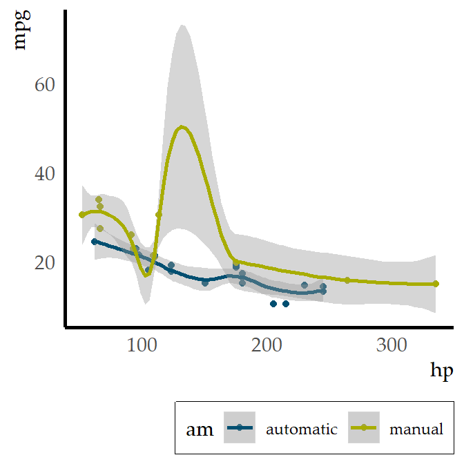

Succinct but awesome caption

```r
library(ggplot2)
mtcars2 <- mtcars
mtcars2$am <- factor(
  mtcars$am, labels = c('automatic', 'manual')
)
ggplot(mtcars2, aes(hp, mpg, color = am)) +
  geom_point() + geom_smooth() +
  theme(legend.position = 'bottom') +
  scale_color_sfsu() +
  theme_sfsu()
```

## Arbitrary Margin Content

You can include anything in the margin using the **knitr** engine named `marginfigure`. Unlike R code chunks `` ```{r} ``, you write a chunk starting with `` ```{marginfigure} `` instead, then put the content in the chunk. See an example on the right about the first fundamental theorem of calculus.

We know from *the first fundamental theorem of calculus* that for $x$ in $[a, b]$:
$$\frac{d}{dx}\left( \int_{a}^{x} f(u)\,du\right)=f(x).$$

## Full Width Figures

You can arrange for figures to span across the entire page by using the chunk option `fig.fullwidth = TRUE`.

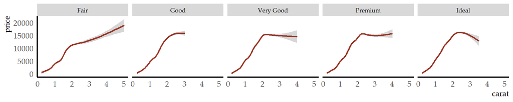

A full width figure.

```r
ggplot(diamonds, aes(carat, price)) +
  geom_smooth(color = "#9A3324") +
  facet_grid(~ cut) +
  theme_sfsu()
```

## Main Column Figures

Besides margin and full width figures, you can of course also include figures constrained to the main column. This is the default type of figures in the LaTeX/HTML output.

A figure in the main column.

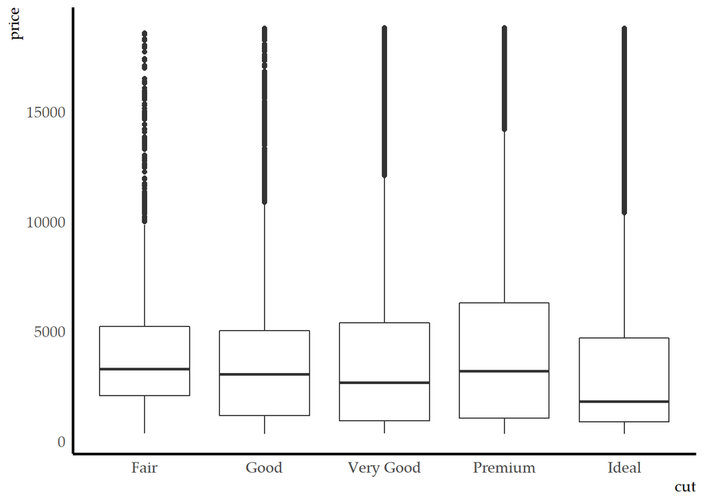

```r
ggplot(diamonds, aes(cut, price)) + geom_boxplot() + theme_sfsu()
```

This is a note and a fun way to call out something important.

# Sidenotes

Tufte loves sidenotes.

This is a sidenote that was entered using a footnote.

You can use the `margin_note()` function from **tufte** in an inline R expression.

This is a margin note.

# Tables

This is `kable` from the **knitr** package:

```r
knitr::kable(
  mtcars[1:6, 1:6], caption = 'A subset of mtcars.'
)
```

A subset of mtcars.

|  | mpg | cyl | disp | hp | drat | wt |
| --- | --- | --- | --- | --- | --- | --- |
| Mazda RX4 | 21.0 | 6 | 160 | 110 | 3.90 | 2.620 |
| Mazda RX4 Wag | 21.0 | 6 | 160 | 110 | 3.90 | 2.875 |
| Datsun 710 | 22.8 | 4 | 108 | 93 | 3.85 | 2.320 |
| Hornet 4 Drive | 21.4 | 6 | 258 | 110 | 3.08 | 3.215 |
| Hornet Sportabout | 18.7 | 8 | 360 | 175 | 3.15 | 3.440 |
| Valiant | 18.1 | 6 | 225 | 105 | 2.76 | 3.460 |

# Block Quotes

Use `>` for block quotes. If you want to add a right-aligned footer for the quote, you may use the function `quote_footer()`:

> “When the people shall have nothing more to eat, they will eat the rich.”